# Plans de gestion des espaces naturels

last updated: 2026-10-12

## Objectifs du cours

- Qu’est-ce qu’un plan de gestion ?
- Pourquoi faire un plan de gestion ?
- Comment faire un plan de gestion ?

## Introduction

## Introduction

Un plan de gestion est un document cadre qui fixe les enjeux et les objectifs de la gestion des espaces naturels.

Méthodolgie commune : CT88 porté par l’OFB

https://ct88.espaces-naturels.fr/

Trame identique pour tous les Plan de gestion.

Contenus et structure du document variable selon les espaces et les enjeux, par conséquent un plan de gestion peu être succinct (< 50 pages) ou très long (plusieurs centaines de pages).

Il est défini pour une durée donnée, en général cinq ou dix ans.

## Introduction

Un plan de gestion est un document de planification.

Objectifs :

- Définir, progammer, contrôler la gestion des milieux naturels
- Assurer à long terme la continuité de la gestion
- Organiser le travail à mettre en œuvre sur le terrain
- Transmettre et expliciter les choix de gestions aux acteurs et usagers locaux

## Schéma général d’un plan de gestion

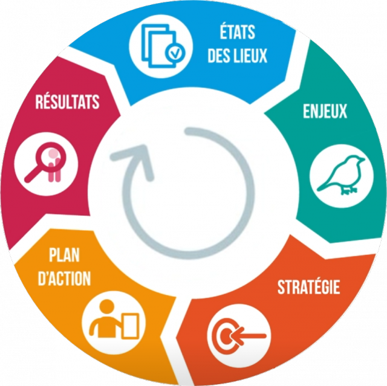

Démarche cyclique (notion de continuité et d’ajustement)

## Application des Plans de gestion

## Quels espaces sont concernés ?

- RNR, RNN
- RBD, RBI
- Sites CEN
- APPB
- Réserve de chasse et de faune sauvage
- Et tout autre site naturel – au sens large – géré avec un objectif de conservation de la biodiversité

En métropole et en outre-mer

[figure not shown]

Exemple : PG de la RNN de la Trinité (Guyane) en trois tomes !

## Qui rédige et applique des plans de gestion ?

- Conservatoires d’espaces naturels (réseau de 25 CEN en France + outre-mer)
- ONF, OFB
- Associations de protection de la Nature (LPO…)
- Collectivités territoriales (Régions, Départements, communes…)
- Industriels (carrières…)

En régie ou prestation (Bureau d’études, association naturaliste)

## Quelques exemples

[figure not shown]

90 p.

[figure not shown]

149 p.

[figure not shown]

135 p.

## Comment est construit un plan de gestion ?

## Plan type

- Diagnostic
- Gestion conservatoire
  - Définition des enjeux
  - Définition des objectifs à long terme
  - Définition des objectifs opérationels
  - Description des opérations
- Fiches actions (e.g. inventaire d’espèces, entretien de milieu, creusage de mare…)
- Bibliographie
- Annexes (cartes, listes d’espèces…)

## Ce que contient un plan de gestion

- Liste des habitats patrimoniaux
- Listes des espèces animales et végétales patrimoniales
- Rappel des enjeux, des objectifs à long terme, des objectifs opérationels et des actions.

## Étape 1 : Le diagnostic

- Diagnostic écologique : faune, flore, habitats.

Les outils disponibles = Arrêtés de protection, Listes rouges, atlas de répartition, Cahiers d’Habitats…

- Diagnostic géologique
- Diagnostic archéologique
- Diagnostic hydrologique : Régime des cours d’eau, identification des eaux stagnantes, connaissance des eaux souterraines.
- Diagnostic économique (e.g. agriculture)
- Diagnostic culturel : monuments, ouvrages, pratiques sportives et de loisir.

## Étape 1 : Le diagnostic

L’utilisation et la fréquentation des sites naturels varient dans l’espace (ville vs. forêt) et dans le temps (e.g. vacances en montagne ou à la mer).

Comment concilier tous ces éléments ? Quelles priorités ?

Point de vigilance : nécessité de veille bibliographique ( = actualisation des connaissances scientifiques)

## Étape 1 : Le diagnostic

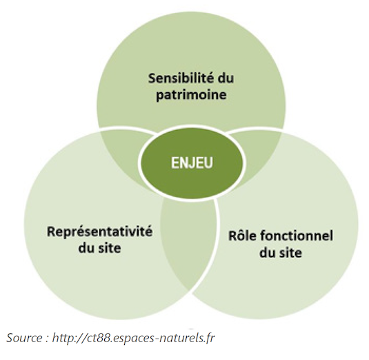

## Exemple : La RNR du Bocage des Antonins (79)

[figure not shown]

[figure not shown]

## Exemple : La RNR du Bocage des Antonins (79)

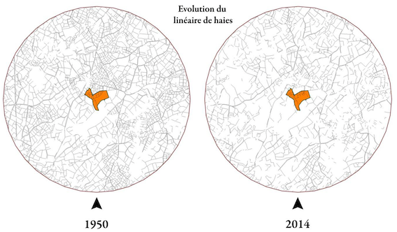

[figure not shown]

## Étape 2 : La définition des objectifs

- Objectifs à long terme : “l’état ou la fonctionnalité souhaitée par rapport à la situation actuelle de l’enjeu, qui doivent être visés afin de préserver cet enjeu”
- Objectifs opérationels : “facteurs naturels et anthropiques qui influencent directement ou indirectement l’existence, l’état et l’évolution des enjeux.”

## Quelques exemples

- Objectifs à long terme : Améliorer les conditions stationnelles d’une mare pour l’accueil de la faune ; Restaurer des conditions stationnelles d’ensoleillement pour l’expression des prairies et espèce associées
- Objectifs opérationnels : Restaurer équilibre en milieux ouverts et milieux forestiers
- Actions : Repousser les lisières ; Entretenir les lisières ; Entretenir une haie arbustive ; Désenvaser une mare…

## Résumé des objectifs

Étape cruciale d’un Plan de gestion.

- Notion d’état de référence
- Quelles espèces/habitats préserver ?
- Quels aménagements sont prioritaires ? Parfois, il faut faire des compromis entre les objectifs de gestion et les moyens financiers et humains à disposition. Notion d’arbitrage.
- Hiérarchisation des enjeux : arbre décisionnel implicite, parfois difficile à appliquer. Quelle espèce serait prioritaire par rapport à une autre ? Nécessité de mise en contexte de la spécificité du site.

Exemple : creuser une mare dans une prairie pour les amphibiens, mais impact sur la flore prairiale.

## Étape 3 : Les outils et moyens à déployer

- Maintien de pratiques agricoles / sylvicoles vs. non-intervention
- Aménagements particuliers (mares…)
- Adaptation des pratiques (pratiques agricoles, sylvicoles, sportives, cynégétiques…)

## Exemple avec une dimension sociologique : la RNR du Bollenberg

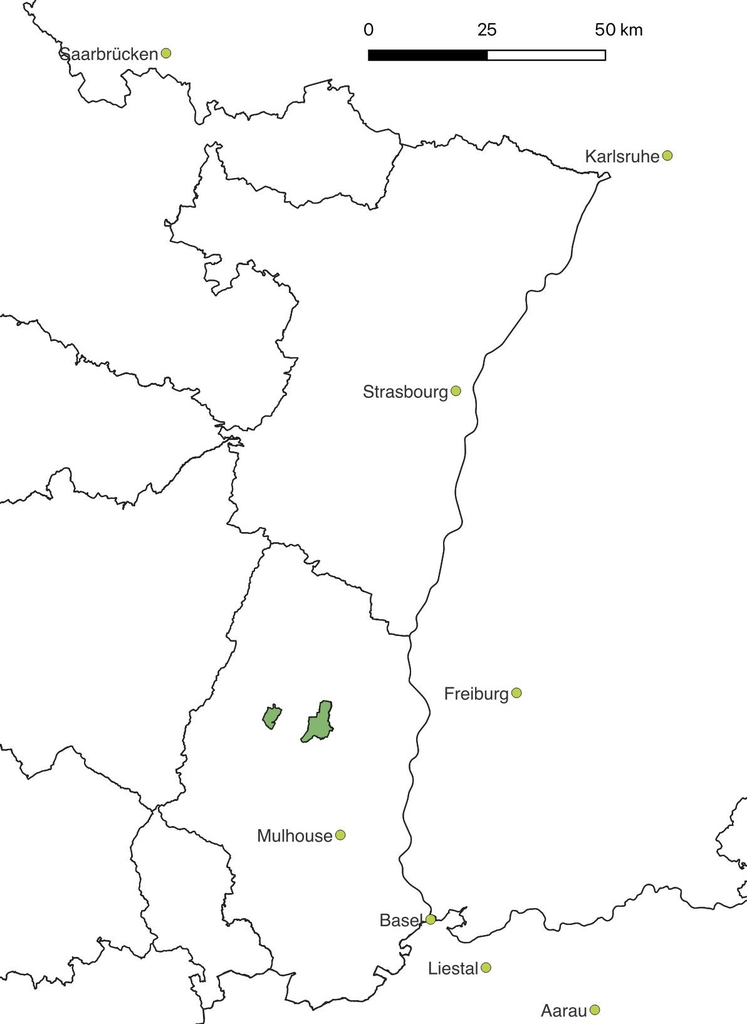

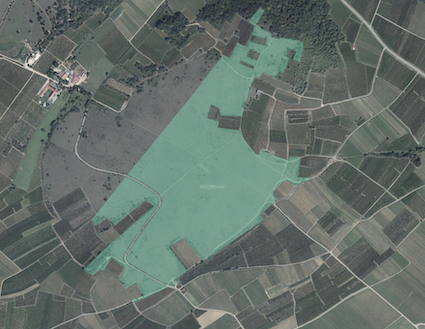

Déplacement d’une piste d’aéromodélisme => conservation de trois plantes protégées : la Cotonnière dressée (*Bombycilaena erecta*), Koelérie du Valais (*Koeleria vallesiana*) et Fumana à tiges retombantes (*Fumana procumbens*). Travail de concertation et de sensibilisation. Nécessité de médiation (Comité consultatif de la RNR)

## Étape 4 : Validation

- Conseil scientifique : CNPN, CSRPN, Conseil scientifique CEN
- Comité consultatif (RNN, RNR)
- Comité de pilotage (Site Natura 2000)

## Étape 5 : Mise en œuvre

- Recherche de financement
- Travaux en régie (CEN, Départements…) ou externalisés (Entreprises privées ou publiques)
- Calendrier des travaux, des inventaires, des suivis

## Les outils pour les Plans de gestion

## Diagnostic des Habitats

Relevés de terrain (phytosociologie)

Référentiels habitats :

- Code Eunis
- Code Natura 2000 (Directive Habitat-Faune-Flore)
- Code CORINE
- Plan d’action (e.g. Plan d’action Tourbières Frache-Comté)

## Diagnostic des espèces

Bibliographie (littérature et BDD naturalistes) + relevés de terrain (inventaires)

- Listes rouge UICN (mondiales, nationales, régionales)
- Espèces protégées
- Liste espèces déterminantes ZNIEFF
- Référentiels taxinomique (e.g. TAXREF)
- Atlas de répartition
- Plans nationaux d’actions

## Cartographie

Utilisation du SIG pour la cartographie des enjeux :

- Cartographie des habitats
- Cartographie des espèces
- Cartographie du patrimoine géologique
- Cartographie des sols
- Cartographie hydrographie/zones humides
- Cartographie des utilisations

## Évaluation des plans de gestion

## Comment évaluer un plan de gestion ?

- Définir des indicateurs : e.g. présence d’une espèce rare, suivi de population,fonctionnalité…
- Suivi des espèces : présence (inventaire), comptage, évaluation de critères démographiques…
- Fonctionnalité : connectivité entre les éléments, pollinisateurs, indices de reproduction, niveaux d’eau… Notions d’écotones et de mosaïque d’habitats

L’évaluation est une étape cruciale qu’il faut planifier mais souvent difficile à mettre en œuvre.

## Exemple : la RNR du Bocage des Antonins (79)

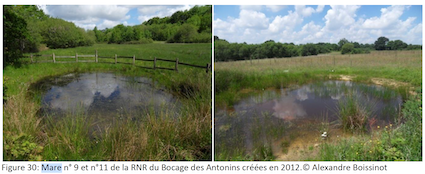

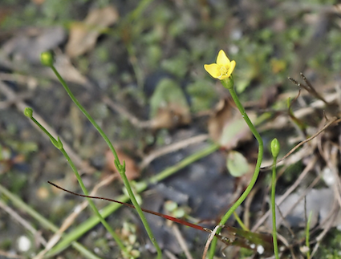

Cicendie filiforme (*Cicendia filiformis*), espèce connue du début XXème siècle retrouvée après creusage de mares

## Quelques références

## Pour aller plus loin

https://ct88.espaces-naturels.fr/guide-delaboration-des-plans-de-gestion

[figure not shown]